# 101: Introduction To R

20 July 2016

## Who Am I?

### Steve Pederson

R User for >10 years

Co-ordinator, Bioinformatics Hub  
Level 4, Santos Petroleum Engineering Building

## Who Am I?

### The Bioinformatics Hub

Also Today:

- Jimmy Breen & Hien To (Bioinformatics Hub)
- Reuben Buckley (Centre For Computational Genetics)
- Mohammad Kamruzzaman (Centre for Water Management and Reuse)

## Who Am I?

### The Bioinformatics Hub

Later This Week:

- Joey Gerlach (eRSA)
- Steve Delean (Biological Sciences)

## Other Information

### Slack

Please join the `#radelaide-2016` channel

### R Drop In

- Previously Wed 12:30 - 2:30
- Now Tues 11am - 1:00pm

## Why use R?

- The main software/language used for analysis of biological data (along with Python)
- Can handle extremely large datasets
- We can easily perform complex analytic procedures
- Many processes come as inbuilt functions
- Huge user base of biological researchers

## Why use R?

### Other Key Reasons

- Avoids common Excel pitfalls
- Reproducible Research

## Automatic Conversion

### A common Excel problem

Excel is notorious for converting values from one thing to another inappropriately.

- Gene names are often converted to dates (e.g. *SEPT9*)
- Genotypes can be converted into numeric values (e.g. the homozygote "1/1")

In `R` we generally work with plain text files.

## Reproducible Research

- Research is littered with mistakes from Excel
- Studies have made Phase III trials
- *We have code to record and exactly repeat our analysis*
- We can find and correct errors more easily than if they are copy/paste errors

## Using R

> **With power comes great responsibility - Uncle Ben**

With this extra capability, we need to understand a little about:

1. Data Types
2. Data Structures

That's tomorrow's content

## Using R

Today we will start with:

1. An Introduction to RStudio
2. Reading data into R
3. Manipulating and cleaning data
4. Visualising data
5. Writing Reports

## Introduction to RStudio

## RStudio

1. Open `RStudio` then
2. `File` > `New File` > `R Script`
3. Save As `Introduction.R`

## RStudio

[figure not shown]

## The Script Window

- This is just a text editor.
- We enter our commands here but they are not executed
  - We can keep a record of **everything** we've done
  - We can also add comments to our code
  - Comments start with the `#` symbol

## The Script Window

[figure not shown]

## The Console

- Where we execute commands
- Is essentially the *"engine"*
- We can execute commands directly in the `Console` or send from the `Script Window`

## Executing Code from the Script Window

Enter the following in the `Script Window`

```r
# Create our first R object
x <- 5
```

- Lines of code are sent to the `Console` by either:
  - `Ctrl + Enter`
  - Copy & Paste into the Console
  - Clicking the `Run` button at the top right

## Executing Commands from the Script Window

We can view the contents of the object `x` by:

- entering it's name directly in the `Console`, or
- entering it's name in the `Script Window` & sending it to the `Console`

```r
x
print(x)
```

## The R Environment

**Where have we created the object `x`?**

- Is it on your hard drive somewhere?
- Is it in a file somewhere?

## The R Environment

- We have placed `x` in our `R Workspace`
- More formally known as your `Global Environment`

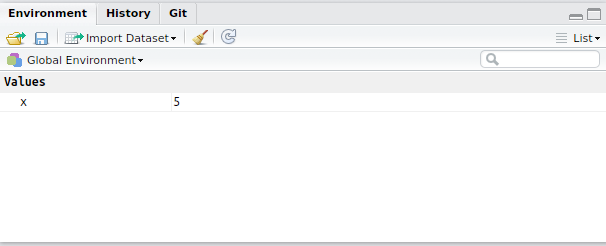

## The R Environment

- The `Environment` is like your desktop
- We keep all our relevant objects here and can save all the objects in your workspace as an `.RData` object

```r
save.image()
```

## The R Environment

- In the R Environment, we can create objects of multiple types.
- We first give them a name (e.g. `x`) and then assign a value to it using the `<-` symbol.
- **This is like an arrow putting the value into the object.**
- Can also work the other way, but is rarely done

```r
# Using the reverse assignment operator
5 -> x
```

## RStudio

### Other Tabs and Features

- Next to the `Environment` Tab is the `History` Tab
  - Contains everything executed in the `Console`
  - Useful for when we've been lazy
- Best coding practice is still to enter code in the `Script Window` and execute

## RStudio

### Other Tabs and Features

In the bottom right are a series of tabs

1. `Files`: This shows your current working directory
2. `Plots`: Every time you make a graph it appears here
3. `Packages`: **NEVER CLICK OR UN-CLICK ANYTHING HERE**
4. `Help`: We'll explore this later

## RStudio

### Other Tabs and Features

- Every tab can be resized using the buttons in the top right
- Window separators can also be be moved

## RStudio

### Cheatsheet and Shortcuts

`Help > Cheatsheets > RStudio IDE Cheat Sheet`

Page 2 has lots of hints:

- `Ctrl + 1` places focus on the Script Window
- `Ctrl + 2` places focus on the Console
- `Ctrl + 3` places focus on the Help Tab

## Introducing Projects

- Projects help keep an analysis organised
- Very useful for managing multiple analyses
- Integrated with `Git` and `SVN` version control
- Always goes back to "where-you-were-last-time"

## Introducing Projects

Let's set one up for this course: `File > New Project`

[figure not shown]

## Introducing Projects

- Choose either a `New` or `Existing` Directory
- Navigate to where you think is suitable for keeping the course notes
- The project name will automatically be assigned as the directory name

[Home](http://uofabioinformaticshub.github.io/RAdelaide-July-2016/)